# Final Assignment Numerical Simulations

## Numerical Simulations Assignment 3

I have tried to show that the Green Paradox holds, and thus the implications of profit discounting means that one is likely to consume stocks of non-renewable resources more quickly if subsidies for green alternatives become a feature. However, this project was slightly too ambitious, so I have decided to see if I can answer one of my former homeworks using Python, so as to assess how Python deals with unknown variables as well as to have a reason to generate reaction curves, a graph I graph I will need for my thesis.

## Contents

`Question`

`Assumptions for the complex model`

`Profit function first order conditions`

`Solving For Equilibrium Quantities`

`Solving for Price and Profit`

`Variable Cost Solutions`

`Reaction Curve assumptions`

`Plotting Reaction Curves`

`Conclusion`

## The `Question` is as follows:

Consider a market consisting of four firms, each of which produces the same product. The inverse market demand for this product is $P = 100 - Q$ ; where P is price and Q is aggregate output.

The production costs for firms 1, 2, and 3 are identical and given by $C(qi) = 20q_i$ $(i = 1; 2; 3)$, where qi is the output of firm i

Note also that if $\alpha > 0$ ; then firm 4 is a high-cost firm, while if $\alpha < 0$; firm 4 is a low-cost firm. Note also that $Q = q_1 + q_2 + q_3 + q_4$

Assume that the fi rms each choose their outputs to maximise pro fits given that they each act as Cournot competitors.

```python
from scipy import optimize,arange
from numpy import array
import matplotlib.pyplot as plt
%matplotlib inline
from sympy import *
from sympy import init_printing
init_printing(use_latex=True)
```

Compute the individual output and the profit for each fi rm as well as the product price in the Nash equilibrium. For this to be a true equilibrium in which all four firms are active, all of the fi rms must at least be covering their variable costs.

Identify the constraints that $\alpha$ must satisfy for this to be the case.

## Our `Assumptions for the complex model`

1. Demand is $P = 100 - Q$
2. Players: [1,2,3,4]
3. Strategy Set: [0,\inft]
4. Payoffs are defined by profits: $\pi_i (q_i , q_j, q_k, q_l) = pq_i -cq_i$
5. costs are: $C(qi) = 20q_i$ $(i = 1; 2; 3)$ and $C(q_4) = (20 + \alpha)q_4$

```python
c1=20
c2=20
c3=20
```

```python
print 'Firm 1 definitions'
q1 = Symbol('q1')
q2 = Symbol('q2')
q3 = Symbol('q3')
q4 = Symbol('q4')
c1=Symbol('20')
c2=Symbol('c2')
c3 = Symbol('c3')
c4 = Symbol('c4')
a=Symbol('100')
y=(a-q1-q2-q3-q4)*q1-c1*q1
yprime = y.diff(q1)
print yprime
```

```
Firm 1 definitions
100 - 20 - 2*q1 - q2 - q3 - q4
```

```python
print ('Firm 2 definitions')
q1 = Symbol('q1')
q2 = Symbol('q2')
q3 = Symbol('q3')
q4 = Symbol('q4')
c1=Symbol('c1')
c2=Symbol('20')
c3=Symbol('c3')
c4=Symbol('c4')
y=(100-q1-q2-q3-q4)*q2-c2*q2
yprime = y.diff(q2)
print yprime
```

```
Firm 2 definitions
-20 - q1 - 2*q2 - q3 - q4 + 100
```

```python
print ('Firm 3 definitions')
q1 = Symbol('q1')
q2 = Symbol('q2')
q3 = Symbol('q3')
q4 = Symbol('q4')
c1=Symbol('c1')
c2=Symbol('c2')
c3=Symbol('20')
c4=Symbol('c4')
y=(100-q1-q2-q3-q4)*q3-c3*q3
yprime = y.diff(q3)
print yprime
```

```
Firm 3 definitions
-20 - q1 - q2 - 2*q3 - q4 + 100
```

```python
print ('Firm 4 defitinitions')
q1 = Symbol('q1')
q2 = Symbol('q2')
q3 = Symbol('q3')
q4 = Symbol('q4')
c1=Symbol('c1')
c2=Symbol('c2')
c3=Symbol('c3')
c4=Symbol('c4')
y=(100-q1-q2-q3-q4)*q4 - (c4*q4)
yprime = y.diff(q4)
print yprime
```

```
Firm 4 defitinitions
-c4 - q1 - q2 - q3 - 2*q4 + 100
```

```python
print ('firm 1')
solve (100 - 20 - 2*q1 - q2 - q3 - q4, q1)
```

```
firm 1
```

$$\left [ - \frac{q_{2}}{2} - \frac{q_{3}}{2} - \frac{q_{4}}{2} + 40\right ]$$

```python
print ('firm 2')
solve (-20 - q1 - 2*q2 - q3 - q4 + 100, q2)
```

```
firm 2
```

$$\left [ - \frac{q_{1}}{2} - \frac{q_{3}}{2} - \frac{q_{4}}{2} + 40\right ]$$

```python
print 'firm 3'
solve (100 - 20 - 2*q3 - q1 - q2 - q4, q3)
```

```
firm 3
```

$$\left [ - \frac{q_{1}}{2} - \frac{q_{2}}{2} - \frac{q_{4}}{2} + 40\right ]$$

```python
print 'firm 4'
solve (- c4 - q1 - q2 - q3 - 2*q4 + 100, q4)
```

```
firm 4
```

$$\left [ - \frac{c_{4}}{2} - \frac{q_{1}}{2} - \frac{q_{2}}{2} - \frac{q_{3}}{2} + 50\right ]$$

## `Profit Function first order conditions`

Thus we find our first order conditions of the profit functions are: $$\frac{\partial{\pi_i}}{\partial{q_i}} = q_i = 40 - \frac{q_j}{2} - \frac{q_k}{2} - \frac{q_4}{2} (where i=1,2,3)$$

And for firm 4: $$\frac{\partial{\pi_4}}{\partial{q_4}} = q_4 = 50 - \frac{q_1}{2} - \frac{q_2}{2} - \frac{q_3}{2} - \frac{c_4}{2}$$

Recall: $c_4=20+\alpha$

Thus $$\frac{\partial{\pi_4}}{\partial{q_4}} = q_4 = 50 - \frac{q_1}{2} - \frac{q_2}{2} - \frac{q_3}{2} - \frac{20+\alpha}{2}$$

So

$$\frac{\partial{\pi_4}}{\partial{q_4}} = q_4 = 50 - \frac{20}{2} - \frac{q_1}{2} - \frac{q_2}{2} - \frac{q_3}{2} - \frac{\alpha}{2} $$

```python
50-(20/2)
```

$$40$$

Finally we have $$\frac{\partial{\pi_4}}{\partial{q_4}} = q_4 = 40 - \frac{q_1}{2} - \frac{q_2}{2} - \frac{q_3}{2} - \frac{\alpha}{2} $$

## `Solving For Equilibrium Quantities`

We need to create a function that can substitute our previous values of $q_1 , q_2 , q_3 , q_4$.

To do this we are going to rearrange our terms to be able to build a matrix.

Firstly $$\frac{\partial{\pi_i}}{\partial{q_i}} = q_i = 40 - \frac{q_j}{2} - \frac{q_k}{2} - \frac{q_4}{2}$$ In the place of $q_4$ we insert: $$\frac{\partial{\pi_4}}{\partial{q_4}} = q_4 = 40 - \frac{q_1}{2} - \frac{q_2}{2} - \frac{q_3}{2} - \frac{\alpha}{2} $$ Giving $$\frac{\partial{\pi_i}}{\partial{q_i}} = q_i = 40 - \frac{q_j}{2} - \frac{q_k}{2} - \frac{40 - \frac{q_i}{2} - \frac{q_j}{2} - \frac{q_k}{2} - \frac{\alpha}{2}}{2}$$

Given $q_1=1_2=q_3=q$ (they are symmetric)

Our New first order conditions are $$80-4q-q_4=0$$ and $$80-\alpha - 2q_4 -3q=0$$

And our system equation solution is, clearly: $$q=16+\frac{1}{5}\alpha$$ and $$q_4=16-\frac{4}{5}\alpha$$

## `Solving for Price and Profit`

$$P = 100 - Q = 100 - 3(16 + \frac{1}{5}\alpha ) - (16 -\frac{4}{5}\alpha) = 36 + \frac{1}{5}\alpha$$

Thus Profits are $$\pi_i = (36 + \frac{1}{5}\alpha) (-16 - \frac{1}{5}\alpha) - 20(-16 - \frac{1}{5}\alpha) = \frac{1}{25}(\alpha + 80)^{2}$$

and

$$\pi_4 = \frac{16}{25}(\alpha-20)^2$$

## `Variable Cost Solutions`

For firm 4 variable costs are covered if $P=(36 + \frac{1}{5}\alpha) > 20+\alpha$ or hence $\alpha<20 $

## Evaluating Reaction Curves

Now let's look at a similar example, but in this case it will be a duopoly where firms are completely semetrical. An alternative way to derive the results it to graphicly depict the reaction curves.

I just pulled the numers here from a basic duopoly example from Game Theory 1

## `Reaction Curve assumptions`

1. Demand is $P = 100 - Q$
2. Players: [1,2]
3. Strategy Set: [0,\inft]
4. Payoffs are defined by profits: $\pi_i (q_i , q_j) = pq_i -cq_i$
5. costs are: $C(qi) = 20q_i$ $(i = 1; 2)$

```python
q1 = Symbol('q1')
q2 = Symbol('q2')
c1=Symbol('20')
c2=Symbol('20')
a=Symbol('100')
y=(a-q1-q2)*q1-c1*q1
yprime = y.diff(q1)
print yprime

q1 = Symbol('q1')
q2 = Symbol('q2')
c1=Symbol('20')
c2=Symbol('20')
a=Symbol('100')
y=(a-q1-q2)*q2-c2*q2
yprime = y.diff(q2)
print yprime
```

```
100 - 20 - 2*q1 - q2
100 - 20 - q1 - 2*q2
```

```python
solve (100 - 20 - 2*q1 - q2,q1)
```

$$\left [ - \frac{q_{2}}{2} + 40\right ]$$

```python
solve (100 - 20 - q1 - 2*q2,q2)
```

$$\left [ - \frac{q_{1}}{2} + 40\right ]$$

```python
import numpy as np
```

```python
a = np.array([[1,.5],[.5,1]])
```

```python
print (a)
```

```
[[ 1.   0.5]
 [ 0.5  1. ]]
```

```python
b = array([40,40])
```

```python
print (a,b)
```

```
(array([[ 1. ,  0.5],
       [ 0.5,  1. ]]), array([40, 40]))
```

```python
z = np.linalg.solve(a,b)
```

```python
print z

print ('Thus we have our quantities above.')
```

```
[ 26.66666667  26.66666667]
Thus we have our quantities above.
```

## `Plotting Reaction Curves`

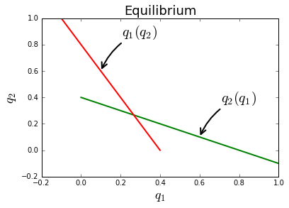

```python
def reaction_function(q_other,c):
    return 0.5*(1-c-q_other)

c_1 = 0.2
c_2 = 0.2

range_q = arange(0.0,1.01,0.01)
range_reaction_1 = [reaction_function(q_2,c_1) for q_2 in range_q]
range_reaction_2 = [reaction_function(q_1,c_2) for q_1 in range_q]

plt.clf()
plt.plot(range_q, range_reaction_2,'-', color = 'g', linewidth = 2)
plt.plot(range_reaction_1, range_q,'-', color = 'r', linewidth = 2)
plt.title("Equilibrium",fontsize = 18)
plt.xlabel("$q_1$",fontsize = 18)
plt.ylabel("$q_2$",fontsize = 18,rotation = 90)
plt.annotate('$q_2(q_1)$', xy=(0.6,reaction_function(0.6,c_2)),  xycoords='data',
              xytext=(30, 50), textcoords='offset points', size = 20,
              arrowprops=dict(arrowstyle="->", linewidth = 2,
                              connectionstyle="arc3,rad=.2"),
              )
plt.annotate('$q_1(q_2)$', xy=(reaction_function(0.6,c_1),0.6),  xycoords='data',
              xytext=(30, 50), textcoords='offset points', size = 20,
              arrowprops=dict(arrowstyle="->", linewidth = 2,
                              connectionstyle="arc3,rad=.2"),
              )

plt.savefig('scenario3.png')
```

## `Conclusion`

Python enables generalised functions which can be adjusted for solving Cournot Problems. That being said, it is difficult if you are using variables which are unknown i.e. undefinable variables.